# Lab-10: Tidytext

Stat 133

Author

Wenyi Shi

**General Instructions**

- Use the template file `lab10-template.qmd` to answer the questions.
- Rename this file as `lab10-first-last.qmd`, where `first` and `last` are your first and last names (e.g. `lab10-gaston-sanchez.qmd`).
- Make sure the YAML header in your `qmd` files includes `embed-resources: true`.
- Submit both your qmd and HTML files to the corresponding assignment submission in bCourses.
- Please note that if you submit the incorrect files you will receive no credit.

This lab requires the following packages:

- `"tidyverse"`: ecosystem of data science packages
- `"tidytext"`: text mining with tidy tools
- `"janeaustenr"`: text of Jane Austen’s novels

# 1 Introduction

The data for this lab involves the text from Jane Austen’s novels that come in the package `"janeaustenr"`.

As we’ve seen it in class, the text of each novel is available as a character vector:

- `emma`: Emma
- `mansfieldpark`: Mansfield Park
- `northangerabbey`: Northanger Abbey
- `persuasion`: Persuasion
- `prideprejudice`: Pride and Prejudice
- `sensesensibility`: Sense and Sensibility

For data manipulation purposes, it’s better if we encapsulate a character vector into a data.frame or a tibble:

```r
pride_dat = tibble(text = prideprejudice)
```

## 1.1 Tokenization

The first step is to **tokenize** the novel’s text, that is, to break the text apart into individual pieces of “information” called **tokens**, also referred to as **words**. This can be easily done with the `"tidytext"` function `unnest_tokens()`:

```r
pride_tokens = unnest_tokens(tbl = pride_dat, output = word, input = text)
head(pride_tokens, 10)
```

```
# A tibble: 10 × 1
   word
   <chr>
 1 pride
 2 and
 3 prejudice
 4 by
 5 jane
 6 austen
 7 chapter
 8 1
 9 it
10 is
```

# 2 Sentiment Analysis using Bing’s Lexicon

`"tidytext"` comes with the `sentiments` dataset that contains a dictionary or **lexicon** (curated by Bing Liu) of words and their associated sentiment.

```r
rbind(head(sentiments, 5), tail(sentiments, 5))
```

```
# A tibble: 10 × 2
   word       sentiment
   <chr>      <chr>
 1 2-faces    negative
 2 abnormal   negative
 3 abolish    negative
 4 abominable negative
 5 abominably negative
 6 zealously  negative
 7 zenith     positive
 8 zest       positive
 9 zippy      positive
10 zombie     negative
```

Bing Liu’s sentiment lexicon contains many English words. Each word has been assigned a sentiment label `positive` or `negative`.

In addition to the `sentiments` dataset, `"tidytext"` also has the `get_sentiments()` function that allows us to obtain more sentiment lexicons:

For example, here’s how to download the `"afinn"` lexicon. Note that R will ask for your permission to download the data.

```r
# this is an interactive function!
get_sentiments("afinn")
```

## 2.1 Sentiment Analysis with Inner Join

Let’s use the `sentiments` data set in order to compute a sentiment score for *Pride and Prejudice*. The sentiments of words can be added to our data table with an inner join via `inner_join()`.

```r
pride_sentiments <- pride_tokens |>
  inner_join(sentiments, by = "word")

head(pride_sentiments, 5)
```

```
# A tibble: 5 × 2
  word      sentiment
  <chr>     <chr>
1 pride     positive
2 prejudice negative
3 good      positive
4 fortune   positive
5 well      positive
```

### 2.1.1 Graphing Frequencies

We can get frequencies of the words and their sentiments, and then graph them with `ggplot()`. Notice that the word `"miss"` is being handled by the sentiment lexicons as related to the verb *to miss*, instead of a title prefixed to the name of a woman as in *miss Emma*. Because of this, `"miss"` gets a negative sentiment.

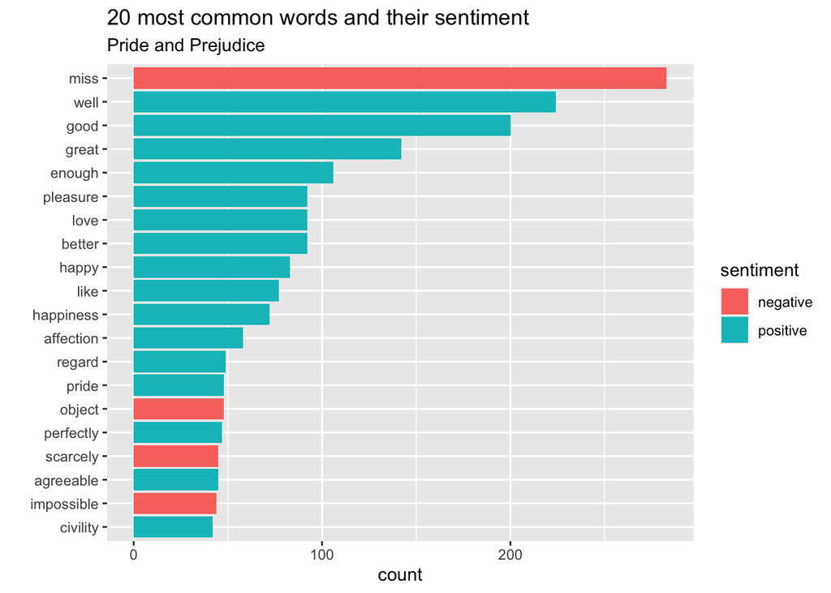

```r
pride_sentiments |>
  count(word, sentiment, sort = TRUE) |>
  slice_head(n = 20) |>
  ggplot() +
  geom_col(aes(y = reorder(word, n), x = n, fill = sentiment)) +
  labs(title = "20 most common words and their sentiment",
       subtitle = "Pride and Prejudice",
       y = "",
       x = "count")
```

## 2.2 Your Turn: Sentiments in Persuasion

Repeat the sentiment analysis steps performed on `prideandprejudice` but now applied on `persuasion`, and create a barchart to visualize the 20 most common words and their associated sentiment.

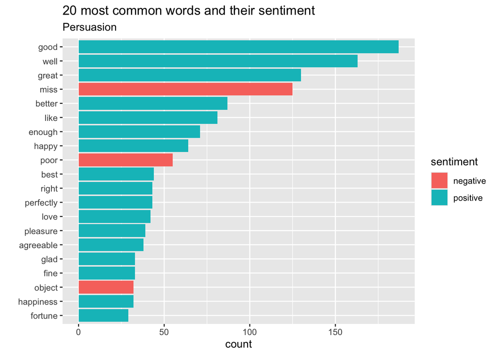

```r
# your code
persuasion_dat = tibble(text = persuasion)
persuasion_tokens = unnest_tokens(tbl = persuasion_dat, output = word, input = text)
persuasion_sentiments <- persuasion_tokens |>
  inner_join(sentiments, by = "word")
persuasion_sentiments |>
  count(word, sentiment, sort = TRUE) |>
  slice_head(n = 20) |>
  ggplot() +
  geom_col(aes(y = reorder(word, n), x = n, fill = sentiment)) +
  labs(title = "20 most common words and their sentiment",
       subtitle = "Persuasion",
       y = "",
       x = "count")
```

# 3 Most Common Positive and Negative Words

We can also analyze word counts that contribute to a given sentiment.

```r
bing_word_counts <- pride_tokens |>
  inner_join(sentiments, by = "word") |>
  count(word, sentiment, sort = TRUE) |>
  ungroup()

head(bing_word_counts)
```

```
# A tibble: 6 × 3
  word   sentiment     n
  <chr>  <chr>     <int>
1 miss   negative    283
2 well   positive    224
3 good   positive    200
4 great  positive    142
5 enough positive    106
6 better positive     92
```

This can be shown visually:

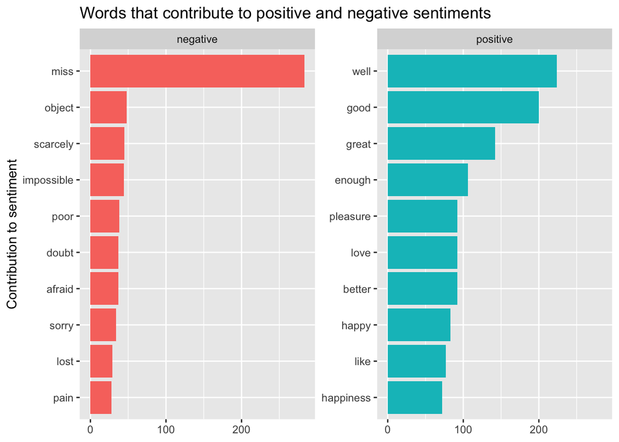

```r
bing_word_counts |>
  group_by(sentiment) |>
  slice_head(n = 10) |>
  ungroup() |>
  mutate(word = reorder(word, n)) |>
  ggplot(aes(y = word, x = n, fill = sentiment)) +
  geom_col(show.legend = FALSE) +
  facet_wrap(~ sentiment, scales = "free_y") +
  labs(y = "Contribution to sentiment",
       x = NULL,
       title = "Words that contribute to positive and negative sentiments")
```

Again, the word `"miss"` is coded as negative because of the verb *to miss*. But in most of Jane Austen’s novels, this word has the connotation of a title for young (unmarried) women. We can create our own custom set of stop-words that includes `"miss"`

```r
custom_stop_words <- bind_rows(
  data.frame(
    word = "miss",
    lexicon = "custom"),
  stop_words
)

head(custom_stop_words, 5)
```

```
   word lexicon
1  miss  custom
2     a   SMART
3   a's   SMART
4  able   SMART
5 about   SMART
```

And then, replot the words that have the largest contribution to positive and negative sentiment in Pride and Prejudice:

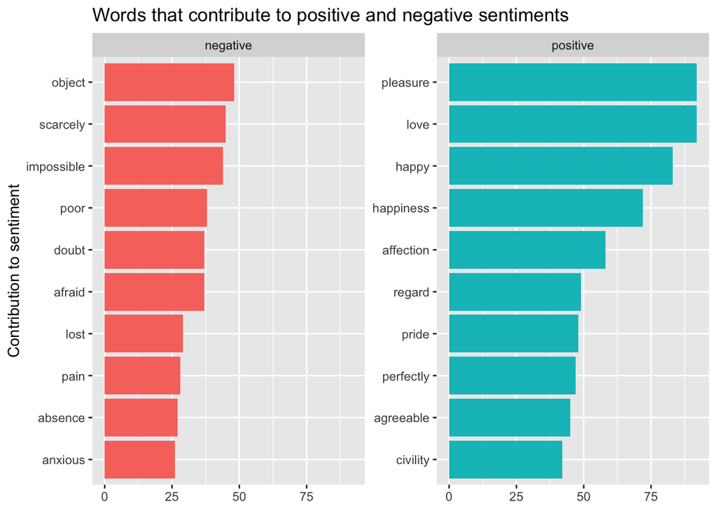

```r
pride_tokens |>
  anti_join(custom_stop_words, by = "word") |>
  inner_join(sentiments, by = "word") |>
  count(word, sentiment, sort = TRUE) |>
  ungroup() |>
  group_by(sentiment) |>
  slice_head(n = 10) |>
  mutate(word = reorder(word, n)) |>
  ggplot(aes(y = word, x = n, fill = sentiment)) +
  geom_col(show.legend = FALSE) +
  facet_wrap(~ sentiment, scales = "free_y") +
  labs(y = "Contribution to sentiment",
       x = NULL,
       title = "Words that contribute to positive and negative sentiments")
```

## 3.1 Your Turn: Contribution to Sentiments in Persuasion

Repeat the contribution to sentiment analysis performed on `prideandprejudice` but now applied on `persuasion`, and create a facet barchart to visualize the 10 most common words associated to each sentiment.

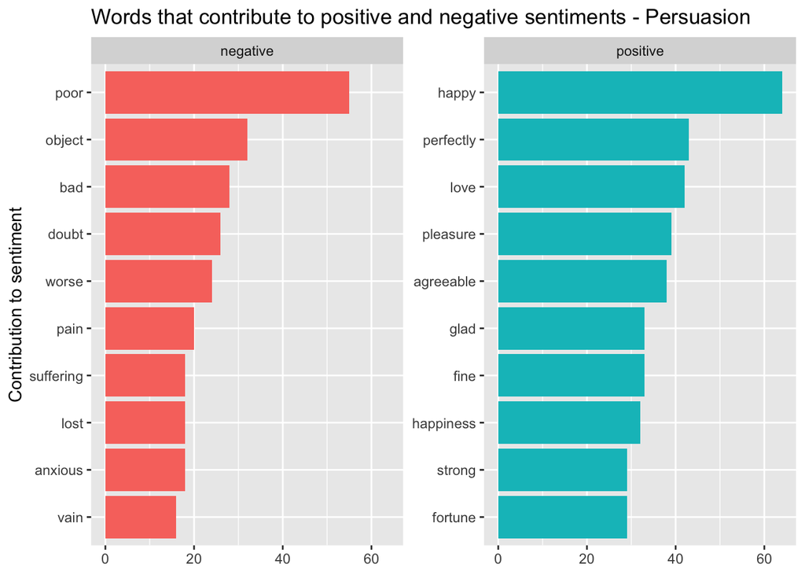

```r
# your code
custom_stop_words <- bind_rows(
  data.frame(
    word = "miss",
    lexicon = "custom"),
  stop_words
)

persuasion_tokens |>
  anti_join(custom_stop_words, by = "word") |>
  inner_join(sentiments, by = "word") |>
  count(word, sentiment, sort = TRUE) |>
  ungroup() |>
  group_by(sentiment) |>
  slice_head(n = 10) |>
  mutate(word = reorder(word, n)) |>
  ggplot(aes(y = word, x = n, fill = sentiment)) +
  geom_col(show.legend = FALSE) +
  facet_wrap(~ sentiment, scales = "free_y") +
  labs(y = "Contribution to sentiment",
       x = NULL,
       title = "Words that contribute to positive and negative sentiments - Persuasion")
```

# 4 Bigrams containing word ‘happy’

```r
# step 1) get bigrams
pride_bigrams <- pride_dat |>
  unnest_tokens(
    output = bigram,
    input = text,
    token = "ngrams",
    n = 2)

# step 2) filter those containing "happy"
bigrams_separated <- pride_bigrams |>
  separate(bigram, c("word1", "word2"), sep = " ")

happy_bigrams = pride_bigrams |>
  filter(str_detect(bigram, "happy")) |>
  count(bigram, sort = TRUE, name = "count")

happy_bigrams |>
  slice_head(n = 10)
```

```
# A tibble: 10 × 2
   bigram     count
   <chr>      <int>
 1 be happy      10
 2 the happy      7
 3 happy to       6
 4 so happy       6
 5 as happy       5
 6 happy as       5
 7 such happy     5
 8 how happy      4
 9 very happy     4
10 a happy        3
```

Once we have those “happy” bigrams, we can plot the top-10:

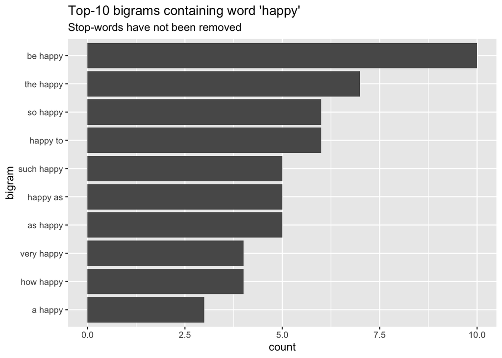

```r
happy_bigrams |>
  slice_head(n = 10) |>
  ggplot(aes(x = count, y = reorder(bigram, count))) +
  geom_col() +
  labs(title = "Top-10 bigrams containing word 'happy'",
       subtitle = "Stop-words have not been removed",
       y = "bigram")
```

## 4.1 Your Turn: Exploring certain bigrams in Persuasion

Based on one or more of the most common sentiment words in `persuasion`, search for their bigrams, and graph the top-10 or the top-15 most common ones.

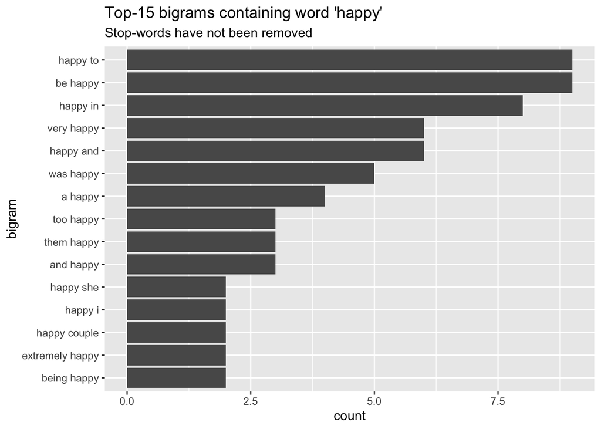

```r
# your code. I will choose word happy since it is also the most positive word in Persuasion.
# step 1) get bigrams
persuasion_bigrams <- persuasion_dat |>
  unnest_tokens(
    output = bigram,
    input = text,
    token = "ngrams",
    n = 2)

# step 2) filter those containing "happy"
persuasion_bigrams_separated <- persuasion_bigrams |>
  separate(bigram, c("word1", "word2"), sep = " ")

persuasion_happy_bigrams = persuasion_bigrams |>
  filter(str_detect(bigram, "happy")) |>
  count(bigram, sort = TRUE, name = "count")

persuasion_happy_bigrams |>
  slice_head(n = 15) |>
  ggplot(aes(x = count, y = reorder(bigram, count))) +
  geom_col() +
  labs(title = "Top-15 bigrams containing word 'happy'",
       subtitle = "Stop-words have not been removed",
       y = "bigram")
```

# 5 Change of sentiments throughout a novel

In addition to focusing on word’s sentiments, we can also take into account the “flow” of sentiments along the text.

## 5.1 Adding a `linenumber` column

To take the idea of *flow* into account, we need to keep track of the “place” or location where a token occurs. To do this, we’ll add an auxiliary column `linenumber` to the data table indicating on which line of text a word occurs. After that, we proceed as usual with the tokenizing phase:

```r
pride_tokens <- pride_dat |>
  mutate(linenumber = row_number()) |>
  unnest_tokens(output = word, input = text)

head(pride_tokens)
```

```
# A tibble: 6 × 2
  linenumber word
       <int> <chr>
1          1 pride
2          1 and
3          1 prejudice
4          3 by
5          3 jane
6          3 austen
```

The next step involves assigning sentiments; we’ll keep using Bing’s lexicon `sentiments`:

```r
pride_sentiments <- pride_tokens |>
  inner_join(sentiments, by = "word")

head(pride_sentiments, n = 5)
```

```
# A tibble: 5 × 3
  linenumber word      sentiment
       <int> <chr>     <chr>
1          1 pride     positive
2          1 prejudice negative
3         11 good      positive
4         11 fortune   positive
5         14 well      positive
```

As you can tell, the first 2 rows correspond to words `pride` and `prejudice`. These words appear in the first line of text: `linenumber = 1`. They are basically the words of the title *Pride and Prejudice*. The word `pride` has a positive sentiment, whereas `prejudice` has a negative sentiment.

## 5.2 Adding an `index` column

Again, because we are interested in the *sentiment flow* of the story, it is convenient to consider blocks or sections of text formed by a certain number of lines. An important question is: how many lines of text should we take into account to define what a “section” is? This is an open ended question and you have to pick a number by trial and error.

In a somewhat arbitrary way, let’s choose 80 lines of text as a reasonable number to divide the entire novel into sections of this size:

```r
pride_sections <- pride_sentiments |>
  count(index = linenumber %/% 80, sentiment)

head(pride_sections)
```

```
# A tibble: 6 × 3
  index sentiment     n
  <dbl> <chr>     <int>
1     0 negative      7
2     0 positive     21
3     1 negative     20
4     1 positive     19
5     2 negative     16
6     2 positive     20
```

Notice the use of the `%/%` operator which is the integer division, and allows us get an index to keep track of where we are in the narrative.

For each section, we’ll obtain a sentiment score by counting the number of positive words minus the number of negative words. This is done with the help of the `pivot_wider()` function:

```r
pride_sentim_flow <- pride_sections |>
  pivot_wider(names_from = sentiment, values_from = n, values_fill = 0) |>
  mutate(sentiment = positive - negative)

head(pride_sentim_flow, 10)
```

```
# A tibble: 10 × 4
   index negative positive sentiment
   <dbl>    <int>    <int>     <int>
 1     0        7       21        14
 2     1       20       19        -1
 3     2       16       20         4
 4     3       19       31        12
 5     4       23       47        24
 6     5       15       49        34
 7     6       18       46        28
 8     7       23       33        10
 9     8       17       48        31
10     9       22       40        18
```

Now we can graph these sentiment scores across the plot trajectory of the novel:

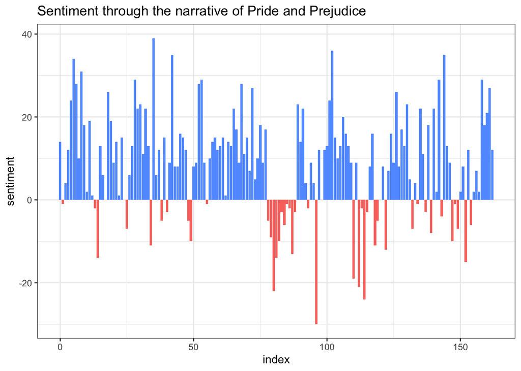

```r
ggplot(data = pride_sentim_flow,
       aes(x = index, y = sentiment, fill = factor(sign(sentiment)))) +
  geom_col(show.legend = FALSE) +
  theme_bw() +
  labs(title = "Sentiment through the narrative of Pride and Prejudice")
```

## 5.3 Your Turn: Sentiment Flow in Persuasion

Repeat the sentiment flow analysis steps performed on `prideandprejudice` but now applied on `persuasion`, and create a barchart to visualize such a flow.

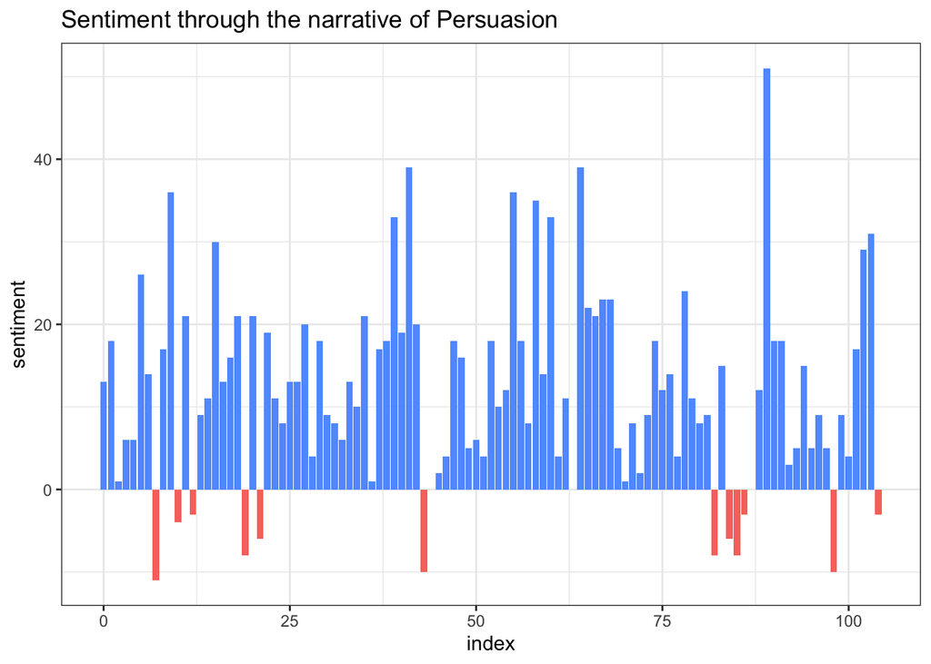

```r
# your code
persuasion_tokens <- persuasion_dat |>
  mutate(linenumber = row_number()) |>
  unnest_tokens(output = word, input = text)

persuasion_sentiments <- persuasion_tokens |>
  inner_join(sentiments, by = "word")

persuasion_sections <- persuasion_sentiments |>
  count(index = linenumber %/% 80, sentiment)

persuasion_sentim_flow <- persuasion_sections |>
  pivot_wider(names_from = sentiment, values_from = n, values_fill = 0) |>
  mutate(sentiment = positive - negative)

ggplot(data = persuasion_sentim_flow,
       aes(x = index, y = sentiment, fill = factor(sign(sentiment)))) +
  geom_col(show.legend = FALSE) +
  theme_bw() +
  labs(title = "Sentiment through the narrative of Persuasion")
```